# Homework 2

## Simple regression modeling of F1_data

Conduct a test whether or not male data is correlated with the female data.

1. I will be using the paired t-test to test to see if the vowel height measurement from men and women.

```r
dataf1 = read.csv("~/Desktop/classes/lingc160/F1_data.csv")
t.test(dataf1$female, dataf1$male, paired = TRUE)
```

```
##
##  Paired t-test
##
## data:  dataf1$female and dataf1$male
## t = 6.1061, df = 18, p-value = 9.076e-06
## alternative hypothesis: true difference in means is not equal to 0
## 95 percent confidence interval:
##   61.48473 125.98895
## sample estimates:
## mean of the differences
##                93.73684
```

Since the p-value is 9.076e-06 and therefore <0.05, we reject the null and conclude that the vowel height measurements for men and women are different.

```r
lm(male ~ female, dataf1)
```

```
##
## Call:
## lm(formula = male ~ female, data = dataf1)
##
## Coefficients:
## (Intercept)       female
##     47.5961       0.7356
```

If female F1 were 796, then the male F1 would be 0.7356*796 + 47.5961 = 633.1337.

3. The predicted male f1 value was lower than the actual. The difference is 678-633.1337, which is about 45. This difference is called the residual.

```r
sum(dataf1$male - (dataf1$female*0.7356 + 47.5961))
```

```
## [1] 0.4493
```

The sum of the residuals is about 0. This is because each residual is the predicted - expected, and the linear regression minimizes the residual values to 0 (which is only true in the case that the formula has an intercept and in this case it does).

## Multiple regression modeling of durationsGe

```r
sub = durationsGe[!is.na(durationsGe$Sex),]
durations = sub
```

1. The subject’s rate of speech during the utterance would be predictive of the duration. This is because the rate of speech is directly related to how long the prefix is spoken for. The faster the rate of speech the shorter the duration and vise versa.

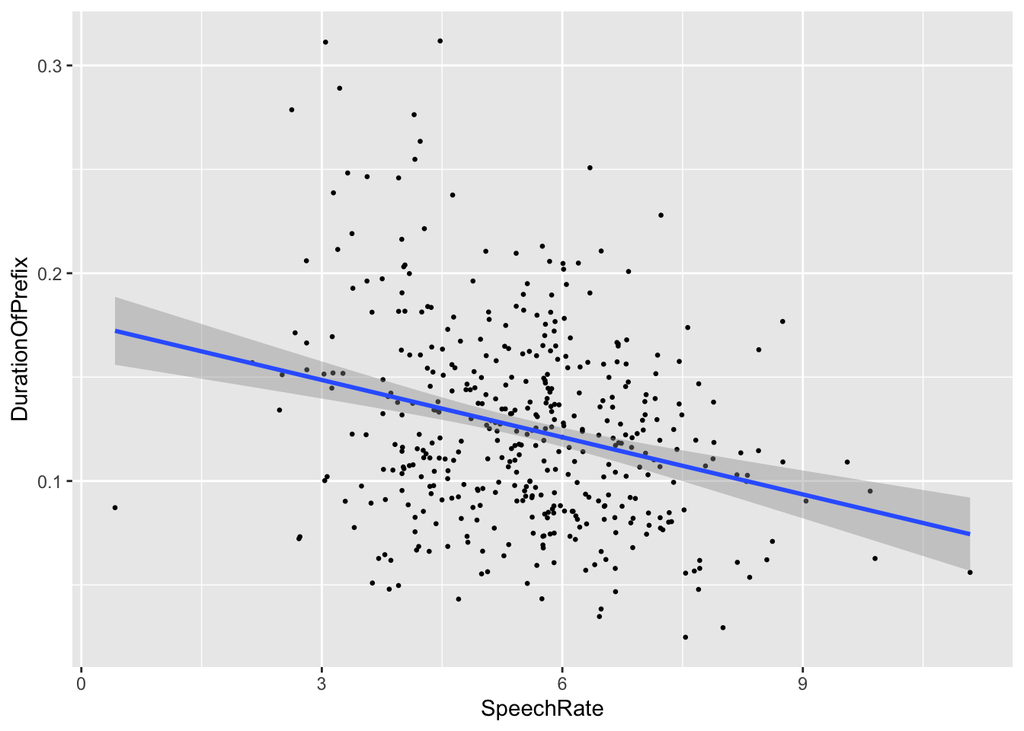

```r
ggplot(durations, aes(SpeechRate, DurationOfPrefix)) + geom_point(size=0.5) +geom_smooth(method="lm")
```

The line suggests that there is a negative correlation between speech rate and duration of the prefix. The faster the speech rate, the shorter the duration of the prefix. This is likely due to the fact that if a person’s speech rate is generally faster, the time taken to say words would be faster, hence the duration of the prefix would be lower.

```r
predictor = lm(DurationOfPrefix~ SpeechRate + Sex + Frequency + NumberSegmentsOnset , durations)

summary(predictor)
```

```
##
## Call:
## lm(formula = DurationOfPrefix ~ SpeechRate + Sex + Frequency +
##     NumberSegmentsOnset, data = durations)
##
## Residuals:
##       Min        1Q    Median        3Q       Max
## -0.095744 -0.031488 -0.000358  0.024367  0.181438
##
## Coefficients:
##                       Estimate Std. Error t value Pr(>|t|)
## (Intercept)          1.866e-01  1.078e-02  17.305  < 2e-16 ***
## SpeechRate          -9.444e-03  1.567e-03  -6.026 3.66e-09 ***
## Sexmale              3.677e-03  4.442e-03   0.828  0.40822
## Frequency           -1.090e-05  4.018e-06  -2.712  0.00696 **
## NumberSegmentsOnset -6.892e-03  3.799e-03  -1.814  0.07032 .
## ---
## Signif. codes:  0 '***' 0.001 '**' 0.01 '*' 0.05 '.' 0.1 ' ' 1
##
## Residual standard error: 0.04528 on 422 degrees of freedom
## Multiple R-squared:  0.09778,    Adjusted R-squared:  0.08923
## F-statistic: 11.43 on 4 and 422 DF,  p-value: 8.055e-09
```

I started out by making four models, the first one starting with 4 predictors.

```r
m1 = lm(DurationOfPrefix~ SpeechRate + Sex + Frequency + NumberSegmentsOnset , durations)

summary(m1)
```

```
##
## Call:
## lm(formula = DurationOfPrefix ~ SpeechRate + Sex + Frequency +
##     NumberSegmentsOnset, data = durations)
##
## Residuals:
##       Min        1Q    Median        3Q       Max
## -0.095744 -0.031488 -0.000358  0.024367  0.181438
##
## Coefficients:
##                       Estimate Std. Error t value Pr(>|t|)
## (Intercept)          1.866e-01  1.078e-02  17.305  < 2e-16 ***
## SpeechRate          -9.444e-03  1.567e-03  -6.026 3.66e-09 ***
## Sexmale              3.677e-03  4.442e-03   0.828  0.40822
## Frequency           -1.090e-05  4.018e-06  -2.712  0.00696 **
## NumberSegmentsOnset -6.892e-03  3.799e-03  -1.814  0.07032 .
## ---
## Signif. codes:  0 '***' 0.001 '**' 0.01 '*' 0.05 '.' 0.1 ' ' 1
##
## Residual standard error: 0.04528 on 422 degrees of freedom
## Multiple R-squared:  0.09778,    Adjusted R-squared:  0.08923
## F-statistic: 11.43 on 4 and 422 DF,  p-value: 8.055e-09
```

Since Sexmale had a p-value > 0.05, this was removed.

```r
m2 = lm(DurationOfPrefix~ SpeechRate + Frequency + NumberSegmentsOnset, durations)

summary(m2)
```

```
##
## Call:
## lm(formula = DurationOfPrefix ~ SpeechRate + Frequency + NumberSegmentsOnset,
##     data = durations)
##
## Residuals:
##       Min        1Q    Median        3Q       Max
## -0.093677 -0.032695 -0.000915  0.025217  0.180055
##
## Coefficients:
##                       Estimate Std. Error t value Pr(>|t|)
## (Intercept)          1.879e-01  1.067e-02  17.603  < 2e-16 ***
## SpeechRate          -9.325e-03  1.560e-03  -5.978  4.8e-09 ***
## Frequency           -1.071e-05  4.010e-06  -2.671  0.00785 **
## NumberSegmentsOnset -7.096e-03  3.789e-03  -1.873  0.06181 .
## ---
## Signif. codes:  0 '***' 0.001 '**' 0.01 '*' 0.05 '.' 0.1 ' ' 1
##
## Residual standard error: 0.04526 on 423 degrees of freedom
## Multiple R-squared:  0.09631,    Adjusted R-squared:  0.08991
## F-statistic: 15.03 on 3 and 423 DF,  p-value: 2.598e-09
```

Since the NumberSegmentsOnset had a p-value > 0.05, this was removed.

```r
m3 = lm(DurationOfPrefix~ SpeechRate + Frequency, durations)

summary(m3)
```

```
##
## Call:
## lm(formula = DurationOfPrefix ~ SpeechRate + Frequency, data = durations)
##
## Residuals:
##      Min       1Q   Median       3Q      Max
## -0.09297 -0.03367 -0.00176  0.02507  0.17574
##
## Coefficients:
##               Estimate Std. Error t value Pr(>|t|)
## (Intercept)  1.768e-01  8.903e-03  19.855  < 2e-16 ***
## SpeechRate  -9.054e-03  1.558e-03  -5.812 1.21e-08 ***
## Frequency   -1.031e-05  4.016e-06  -2.566   0.0106 *
## ---
## Signif. codes:  0 '***' 0.001 '**' 0.01 '*' 0.05 '.' 0.1 ' ' 1
##
## Residual standard error: 0.0454 on 424 degrees of freedom
## Multiple R-squared:  0.08882,    Adjusted R-squared:  0.08452
## F-statistic: 20.67 on 2 and 424 DF,  p-value: 2.728e-09
```

All predictors now have a p-value < 0.05.

I then ran AIC and BIC to see which test preferred which model the most.

```r
AIC(m1, m2, m3)
```

```
##    df       AIC
## m1  6 -1424.302
## m2  5 -1425.609
## m3  4 -1424.084
```

```r
BIC(m1, m2, m3)
```

```
##    df       BIC
## m1  6 -1399.962
## m2  5 -1405.325
## m3  4 -1407.857
```

Our information criteria do differ with respect to what model they ultimately prefer. AIC prefers m2, while BIC prefers m3. This may be because BIC prefers more parsimonious models than AIC.(BIC prefers simpler models while AIC models closer to reality with more complex predictors)

```r
m4 = lm(DurationOfPrefix~ SpeechRate + Frequency + (Sex*NumberSegmentsOnset), durations)

summary(m4)
```

```
##
## Call:
## lm(formula = DurationOfPrefix ~ SpeechRate + Frequency + (Sex *
##     NumberSegmentsOnset), data = durations)
##
## Residuals:
##       Min        1Q    Median        3Q       Max
## -0.096612 -0.031364 -0.000173  0.024618  0.179983
##
## Coefficients:
##                               Estimate Std. Error t value Pr(>|t|)
## (Intercept)                  1.825e-01  1.206e-02  15.135  < 2e-16 ***
## SpeechRate                  -9.337e-03  1.574e-03  -5.930 6.31e-09 ***
## Frequency                   -1.099e-05  4.022e-06  -2.731  0.00657 **
## Sexmale                      1.135e-02  1.112e-02   1.020  0.30816
## NumberSegmentsOnset         -4.376e-03  5.062e-03  -0.864  0.38781
## Sexmale:NumberSegmentsOnset -5.767e-03  7.665e-03  -0.752  0.45225
## ---
## Signif. codes:  0 '***' 0.001 '**' 0.01 '*' 0.05 '.' 0.1 ' ' 1
##
## Residual standard error: 0.0453 on 421 degrees of freedom
## Multiple R-squared:  0.09899,    Adjusted R-squared:  0.08829
## F-statistic: 9.251 on 5 and 421 DF,  p-value: 2.274e-08
```

```r
anova(m3, m4)
```

```
## Analysis of Variance Table
##
## Model 1: DurationOfPrefix ~ SpeechRate + Frequency
## Model 2: DurationOfPrefix ~ SpeechRate + Frequency + (Sex * NumberSegmentsOnset)
##   Res.Df     RSS Df Sum of Sq      F Pr(>F)
## 1    424 0.87379
## 2    421 0.86403  3 0.0097511 1.5837 0.1927
```

According to the F-test, adding the predictor of the two other predictor interaction term does not affect the DurationOfPrefix beyond the predictors SpeechRate and Frequency.This is because the p-value of the F test is > 0.05 (0.1927 > 0.05).